# Bayesian Analysis of a 2×2 Factorial Reaction Time Experiment in R

Demonstrating Simple Bayesian Workflows in Psychology Research

code

analysis

bayesian

A complete Bayesian workflow in R, from simulating a 2×2 reaction time experiment through to fitting a mixed-effects model with brms and interpreting the posterior.

Author

Ho Chin Wei

Published

20 October 2026

# Overview

This document demonstrates a complete **Bayesian analysis pipeline in R** for a simple reaction time experiment with a 2×2 factorial design. The goal is to show, in a clear and reproducible way, how to move from a simulated dataset to a fitted Bayesian mixed-effects model, and then on to interpretation of the posterior, predictions, and basic hypothesis tests.

The focus here is practical. I assume you are comfortable with basic R, regression-type models, and the idea of random effects, but perhaps newer to Bayesian modelling with `brms`. Throughout, I explain the key Bayesian concepts that are directly relevant to the workflow, including priors, posterior distributions, mixed-effects modelling, and MCMC sampling.

# Scenario and Data Simulation

## Experimental Scenario

The example is grounded in a cognitive psychology setting. Imagine an experiment where participants respond to visual targets while two experimental factors are manipulated. The first factor is **Viewing Condition**, where participants either have a *Restricted* view or an *Unrestricted* view of some relevant aspect of the display. The second factor is **Target Location**, which can be *Same* or *Different* relative to a previous location.

The outcome of interest is **reaction time (RT)** in milliseconds. In line with typical inhibition-of-return paradigms, the data are simulated so that responses are slower when the target appears in the **same** location compared to a different one. The expected inhibition effect is around 20–30 ms. Viewing condition is not expected to have a strong effect, and there is no strong interaction between viewing condition and target location.

## Setup and Data Generation

To begin, I load the necessary packages and set a seed for reproducibility. The main packages used are `tidyverse` for data handling, `brms` for the Bayesian modelling, `bayestestR` and `bayesplot` for working with the posterior, and `tidybayes` for tidy posterior extraction.

```r
library(tidyverse) # Data wrangling and visualisation
library(brms) # Bayesian regression models (Stan backend)
library(bayestestR) # Posterior summaries and hypothesis tests
library(bayesplot) # Posterior visualisation tools
library(tidybayes) # Tidy extraction of posterior samples

set.seed(42)
```

Next, I create a trial-level dataset that reflects the 2×2 design and the expected pattern of means. 30 participants complete 24 trials per condition, producing a reasonably sized data set to resemble a modest laboratory sample.

```r
# Parameters for simulation
n_subj   <- 30          # Number of participants
n_trials <- 24          # Trials per condition per participant

# Define cell means (ms), one row per condition so there's no risk of the
# means lining up with the wrong condition (expand.grid()'s row order isn't
# always what you'd guess - listing conditions explicitly avoids that trap)
# These values encode a ~25 ms inhibition effect for "Same" vs. "Different"
mu_table <- tribble(
  ~Viewing,       ~Location,    ~mean, ~sd,
  "Restricted",   "Same",         530,  30,
  "Restricted",   "Different",    505,  30,
  "Unrestricted", "Same",         525,  30,
  "Unrestricted", "Different",    500,  30
)

# Generate trial-level data
dat <- expand.grid(
  Subj     = 1:n_subj,
  Viewing  = c("Restricted", "Unrestricted"),
  Location = c("Same", "Different"),
  Trial    = 1:n_trials
) %>%
  left_join(mu_table, by = c("Viewing", "Location")) %>%
  mutate(
    RT      = rnorm(n(), mean = mean, sd = sd),
    Subj    = factor(Subj),
    Viewing = factor(Viewing, levels = c("Restricted", "Unrestricted")),
    Location = factor(Location, levels = c("Different", "Same"))
  ) %>%
  select(Subj, Viewing, Location, Trial, RT)

head(dat, 12)
```

```
   Subj    Viewing Location Trial       RT
1     1 Restricted     Same     1 571.1288
2     2 Restricted     Same     1 513.0591
3     3 Restricted     Same     1 540.8939
4     4 Restricted     Same     1 548.9859
5     5 Restricted     Same     1 542.1280
6     6 Restricted     Same     1 526.8163
7     7 Restricted     Same     1 575.3457
8     8 Restricted     Same     1 527.1602
9     9 Restricted     Same     1 590.5527
10   10 Restricted     Same     1 528.1186
11   11 Restricted     Same     1 569.1461
12   12 Restricted     Same     1 598.5994
```

At this point, I briefly check that the simulation behaves as intended. The condition means should show longer RTs in the *Same* condition than in the *Different* condition, with only small differences between viewing conditions.

```r
dat %>%
  group_by(Viewing, Location) %>%
  summarise(
    mean_RT = mean(RT),
    sd_RT   = sd(RT),
    n       = n(),
    .groups = "drop"
  )
```

```
# A tibble: 4 × 5
  Viewing      Location  mean_RT sd_RT     n
  <fct>        <fct>       <dbl> <dbl> <int>
1 Restricted   Different    504.  28.3   720
2 Restricted   Same         530.  31.0   720
3 Unrestricted Different    499.  30.3   720
4 Unrestricted Same         526.  30.6   720
```

This simple summary reassures us that the simulated dataset captures the qualitative pattern we designed.

# Fitting the Bayesian Model

With the data in hand, we now fit a Bayesian mixed-effects model. The outcome is `RT`, the fixed effects are `Viewing`, `Location`, and their interaction, and we include a random intercept for `Subj` to account for the fact that multiple trials come from the same participant.

## Priors

Before fitting, it’s worth being explicit about the priors. `brms` will pick default (flat or very weakly informative) priors automatically, but a Bayesian workflow is more transparent when priors are chosen deliberately. Here I use weakly informative priors centred on plausible values given the scale of the data (reaction times in the 400-600ms range, with an expected effect of a few tens of milliseconds):

- **Intercept**: `normal(500, 100)` - centred on a plausible average RT, wide enough to not rule out much.
- **Fixed-effect coefficients** (`b`): `normal(0, 50)` - centred on “no effect”, allowing effects up to roughly +/-100ms to be plausible a priori.
- **Residual and random-intercept SDs**: `exponential(1)` - a standard weakly informative choice for scale parameters, keeping them positive and not too large.

```r
priors <- c(
  prior(normal(500, 100), class = Intercept),
  prior(normal(0, 50),   class = b),
  prior(exponential(1),  class = sigma),
  prior(exponential(1),  class = sd)
)
```

## Model fit

```r
fit <- brm(
  formula = RT ~ Viewing * Location + (1 | Subj),
  data    = dat,
  family  = gaussian(),
  prior   = priors,
  chains  = 4,
  cores   = 4,
  iter    = 2000,
  warmup  = 1000,
  seed    = 42,
  backend = "rstan"
)
```

`chains = 4` runs four independent MCMC chains so we can check they agree with each other (a key diagnostic for whether sampling has worked properly). `warmup = 1000` discards the first 1000 iterations per chain while the sampler tunes itself, keeping the remaining 1000 per chain (4000 total) as usable posterior draws.

## MCMC diagnostics

Before trusting any of the results, we check that the chains converged. `Rhat` values close to 1.00 indicate the chains agree with each other, and `Bulk_ESS`/`Tail_ESS` indicate how many effectively independent draws we have.

```r
summary(fit)
```

```
 Family: gaussian
  Links: mu = identity; sigma = identity
Formula: RT ~ Viewing * Location + (1 | Subj)
   Data: dat (Number of observations: 2880)
  Draws: 4 chains, each with iter = 2000; warmup = 1000; thin = 1;
         total post-warmup draws = 4000

Multilevel Hyperparameters:
~Subj (Number of levels: 30)
              Estimate Est.Error l-95% CI u-95% CI Rhat Bulk_ESS Tail_ESS
sd(Intercept)     0.54      0.44     0.02     1.67 1.00     2576     2339

Regression Coefficients:
                                 Estimate Est.Error l-95% CI u-95% CI Rhat
Intercept                          504.51      1.14   502.22   506.70 1.00
ViewingUnrestricted                 -5.23      1.58    -8.32    -2.17 1.00
LocationSame                        25.47      1.59    22.36    28.56 1.00
ViewingUnrestricted:LocationSame     0.82      2.21    -3.55     5.23 1.00
                                 Bulk_ESS Tail_ESS
Intercept                            3692     3248
ViewingUnrestricted                  3709     3173
LocationSame                         3509     3096
ViewingUnrestricted:LocationSame     3098     2992

Further Distributional Parameters:
      Estimate Est.Error l-95% CI u-95% CI Rhat Bulk_ESS Tail_ESS
sigma    29.94      0.39    29.21    30.72 1.00     6690     1974

Draws were sampled using sampling(NUTS). For each parameter, Bulk_ESS
and Tail_ESS are effective sample size measures, and Rhat is the potential
scale reduction factor on split chains (at convergence, Rhat = 1).
```

# Interpreting the Posterior

## Posterior summaries

`bayestestR` gives a tidy summary of each parameter’s posterior distribution, including the median estimate and a 95% credible interval (the range within which we believe the true value plausibly falls, given the model and data).

```r
describe_posterior(fit, effects = "fixed")
```

```
Summary of Posterior Distribution

Parameter                        | Median |           95% CI |     pd
---------------------------------------------------------------------
(Intercept)                      | 504.53 | [502.22, 506.70] |   100%
ViewingUnrestricted              |  -5.24 | [ -8.32,  -2.17] | 99.98%
LocationSame                     |  25.45 | [ 22.36,  28.56] |   100%
ViewingUnrestricted:LocationSame |   0.82 | [ -3.55,   5.23] | 65.10%

Parameter                        |          ROPE | % in ROPE |  Rhat |  ESS
---------------------------------------------------------------------------
(Intercept)                      | [-3.28, 3.28] |        0% | 1.000 | 3573
ViewingUnrestricted              | [-3.28, 3.28] |     9.16% | 1.000 | 3669
LocationSame                     | [-3.28, 3.28] |        0% | 1.000 | 3446
ViewingUnrestricted:LocationSame | [-3.28, 3.28] |    88.34% | 1.001 | 3065
```

## Visualizing the posterior

The plot below shows the posterior distribution for each fixed-effect coefficient - essentially, how much belief the model places on each possible effect size after seeing the data.

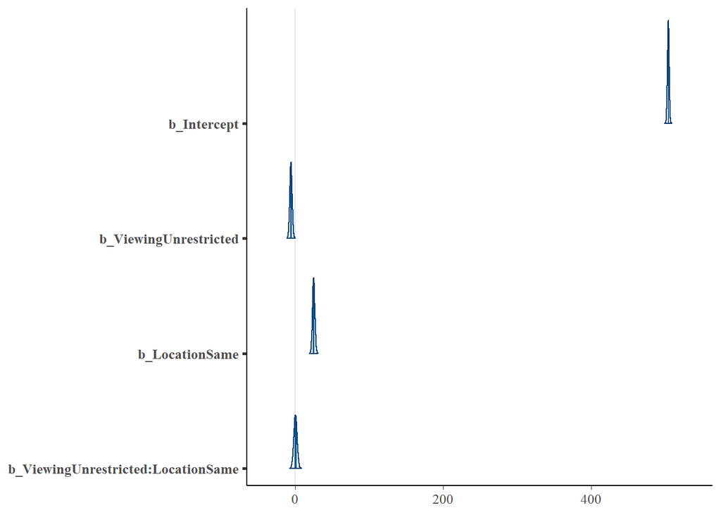

Posterior distributions of the fixed-effect coefficients.

```r
mcmc_plot(fit, type = "areas", variable = "^b_", regex = TRUE)
```

`tidybayes` lets us extract the posterior draws for the effect we care most about - the difference in RT between the *Same* and *Different* location conditions (our simulated inhibition-of-return effect) - and plot its full distribution directly.

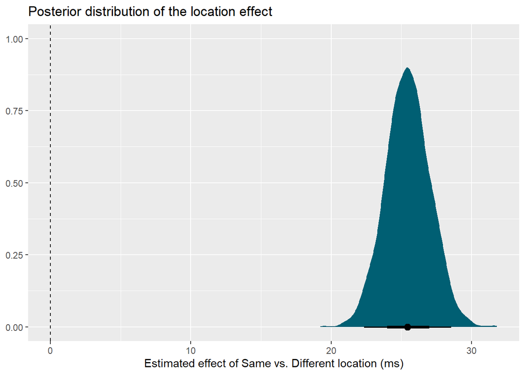

Posterior distribution of the Same vs. Different location effect (ms).

```r
fit %>%
  spread_draws(b_LocationSame) %>%
  ggplot(aes(x = b_LocationSame)) +
  stat_halfeye(fill = "#005F73") +
  geom_vline(xintercept = 0, linetype = "dashed") +
  labs(
    x = "Estimated effect of Same vs. Different location (ms)",
    y = NULL,
    title = "Posterior distribution of the location effect"
  )
```

# Hypothesis Test

A common question in this kind of design is directional: *is reaction time credibly slower in the Same condition than the Different condition?* `brms` lets us test this directly against the posterior via `hypothesis()`, which returns an **Evidence Ratio** - how much more likely the posterior draws support the stated hypothesis versus its complement.

```r
hypothesis(fit, "LocationSame > 0")
```

```
Hypothesis Tests for class b:
          Hypothesis Estimate Est.Error CI.Lower CI.Upper Evid.Ratio Post.Prob
1 (LocationSame) > 0    25.47      1.59    22.84     28.1        Inf         1
  Star
1    *
---
'CI': 90%-CI for one-sided and 95%-CI for two-sided hypotheses.
'*': For one-sided hypotheses, the posterior probability exceeds 95%;
for two-sided hypotheses, the value tested against lies outside the 95%-CI.
Posterior probabilities of point hypotheses assume equal prior probabilities.
```

# Posterior Predictive Check

Finally, it’s good practice to check that the fitted model can generate data that looks like the data we actually observed. A posterior predictive check simulates new datasets from the model’s posterior and overlays their distribution (light lines) against the real data (dark line, `y`). If the model is reasonable, the simulated distributions should closely track the real one.

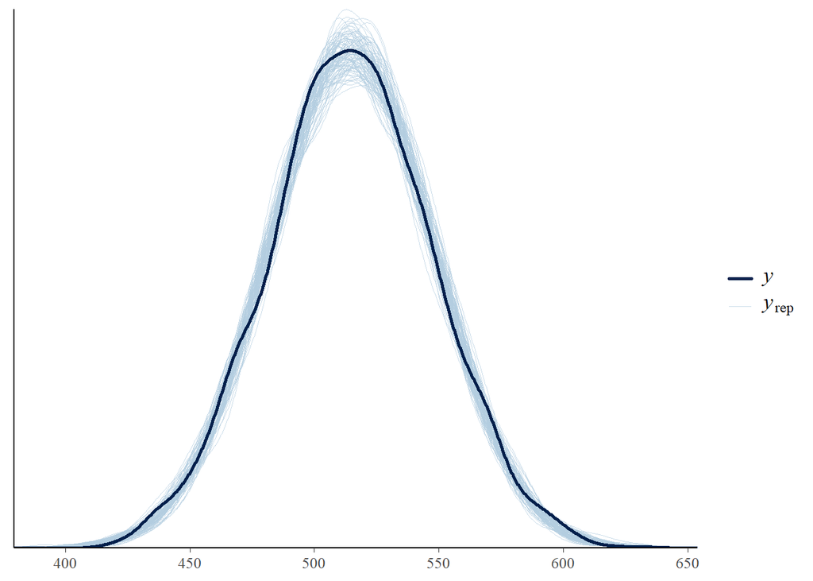

Posterior predictive check: simulated RT distributions (light) vs. observed RT distribution (dark).

```r
pp_check(fit, ndraws = 100)
```

# Summary

This workflow moved from a simulated 2x2 factorial dataset through model specification (including explicit, weakly informative priors), model fitting with `brms`, MCMC convergence checks, posterior summarisation and visualisation, a directional hypothesis test via evidence ratios, and a posterior predictive check. The same steps generalise directly to real experimental data - simply swap the simulated `dat` object for an imported dataset with the same column structure.